# Math 490 HW #5

Maxwell Levin

February 1, 2018

## Question 1.

#### Given a sequence $\small{X_1, X_2,\dots}$ of U[0,1]-distributed psuedo random numbers, we can use a scatter plot of $\small{(X_i, X_{i+1})}$ for $\small{1, \dots, n-1}$ in order to assess whether the $\small{X_i}$ are independent.

#### a. Create such a plot using the built-in random number generator of R, and explain the resulting plot.

We can create such a plot using the following code:

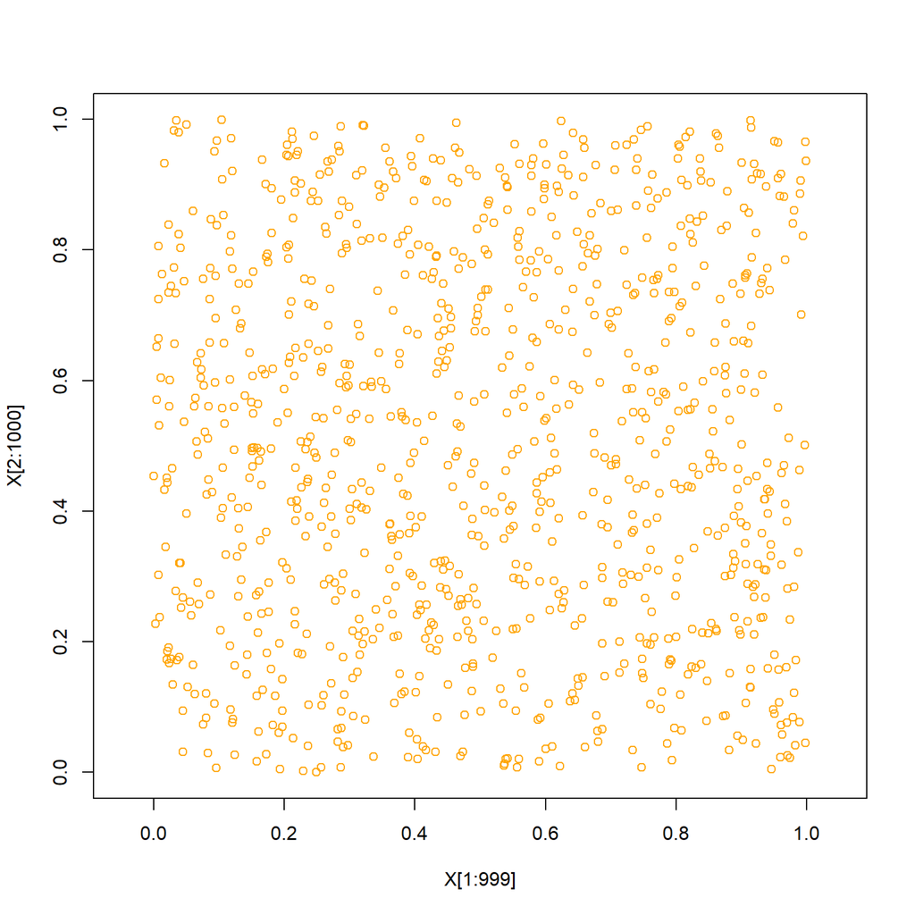

```r
X = runif(1000)
plot(X[1:999], X[2:1000], asp=1, col="orange")
```

As far as I can tell the psuedo-random number built into R does a good job of generating random numbers, as I see no discernable patterns in this plot.

#### b. Create a similar plot, using your LCG code from class:

```r
lcg = function(n, slope, intercept, mod, seed=0) {
  output = seed
  for (i in 1:n) {
    x = (slope*seed + intercept) %% mod
    output = c(output, x)
    seed = x
  }
  output/mod;
}
```

We can run the following code to create a similar plot using our class’s lcg function:

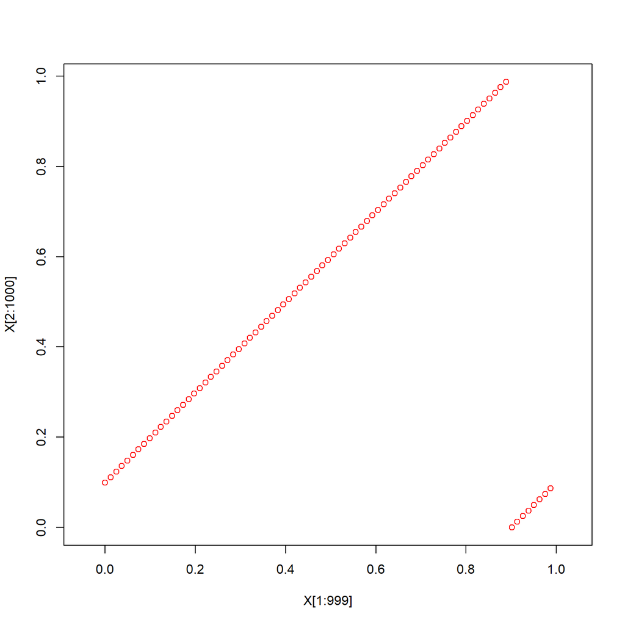

```r
slope = 1
intercept = 8
mod = 81
seed = 0
X = lcg(1000, slope, intercept, mod, seed)
plot(X[1:999], X[2:1000], asp=1, col="red")
```

#### c. Repeat the experiment from (b) with $\small{m = 1024}$, $\small{a = 401}$, $\small{c = 101}$, and $\small{m = 2^{32}}$, $\small{a = 1664525}$, $\small{c = 1013904223}$. Discuss the results.

Let’s run the first simulation:

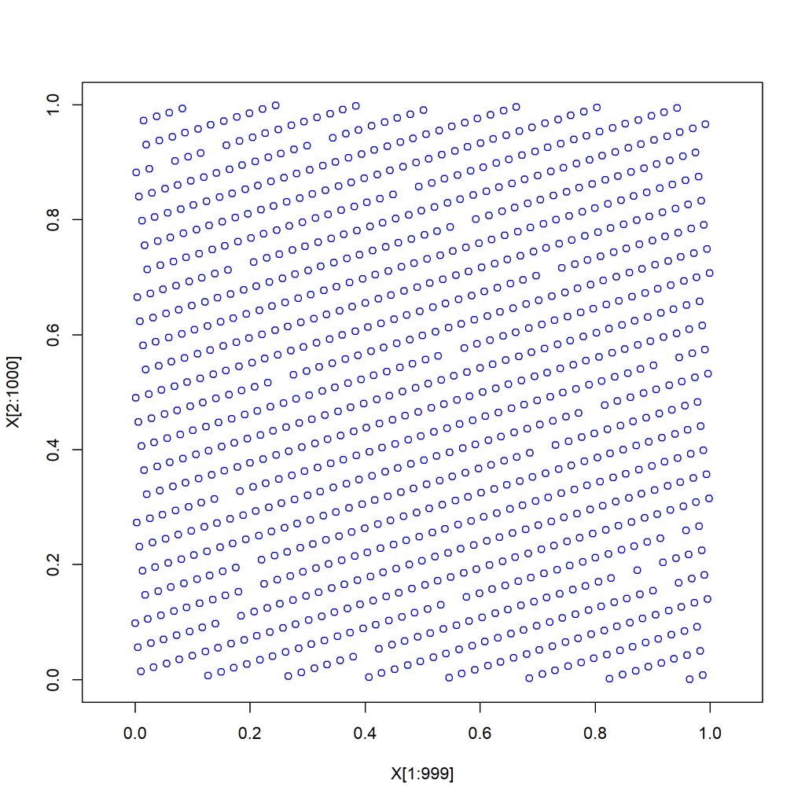

```r
slope = 401
intercept = 101
mod = 1024
X = lcg(1000, slope, intercept, mod)
plot(X[1:999], X[2:1000], asp=1, col="blue")
```

This plot does not seem very random, as each ordered pair is uniformly spaced between its neighbors in a grid-like fashion.

Now we run the simulation again with the suggested parameters:

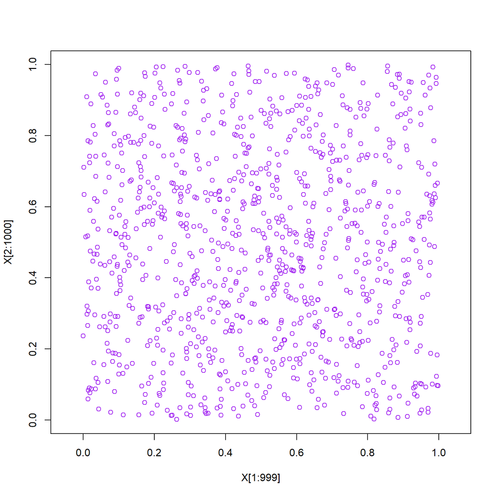

```r
slope = 1664525
intercept = 1013904223
mod = 2^32
X = lcg(1000, slope, intercept, mod)
plot(X[1:999], X[2:1000], asp=1, col="purple")
```

This plot seems much more random and I cannot see a pattern with just 1000 numbers.

## Question 2.

#### Given a sequence $\small{X_1, X_2,\dots}$ of U[0,1]-distributed psuedo random numbers, we can use a scatter plot of $\small{(X_i, X_{i+1})}$ for $\small{1, \dots, n-1}$ in order to assess whether the $\small{X_i}$ are independent.

#### a. Create such a plot using the built-in random number generator of R, and explain the resulting plot.

We can create such a plot using the following code:

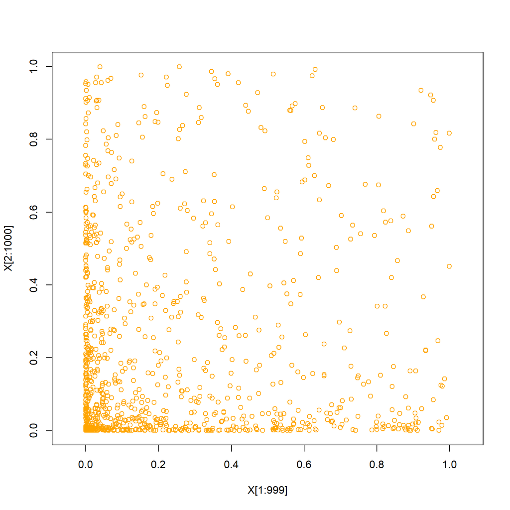

```r
X = runif(1000)^3
plot(X[1:999], X[2:1000], asp=1, col="orange")
```

We see that when we cube each random number we get a plot that is mostly on the left and lower parts of our plot. This makes sense because R generates random numbers between 0 and 1 by default, and when we cube such numbers we know that they will decrease, thus we expect a large portion of our 1000 random numbers to have small X and Y values.